# Exploratory Data Analysis

### `! git clone https://github.com/ds4e/EDA`

## Exploratory Data Analysis

- Once the data are cleaned up, we'll want to do some basic statistical summaries and visualizations to understand their fundamental properties and whether they are clean enough to proceed, and this is called **Exploratory Data Analysis**
- We'll focus on cranking graphs out and their rough interpretation, not thinking too seriously about them as analytics
- We'll introduce the Seaborn package alongside the Pandas plots
- Last time, we cleaned the pretrial data, which works well for visualizations: There are many interesting numeric variables, categorical variables, and dummy variables. We'll use it again today.
- You probably know most or all of the ideas introduced, but perhaps not in Pandas and Seaborn

```python
import numpy as np
import pandas as pd
import matplotlib.pyplot as plt # Pandas automatically uses some pyplot functions, so we need it loaded

df = pd.read_csv('./data/pretrial_data.csv') # Local file

## Transform some badly scaled variables:
df['bond_arcsinh'] = np.arcsinh(df['bond'])
df['sentence_arcsinh'] = np.arcsinh(df['sentence'])
df['prior_F_arcsinh'] = np.arcsinh(df['prior_F'])
df['prior_M_arcsinh'] = np.arcsinh(df['prior_M'])

print(df.head(),'\n')
# print(df.describe(),'\n')
```

```
   Unnamed: 0 case_type   age sex race  is_poor  bond  bond_type  prior_F  \
0           0         F  31.0   M    W      NaN   NaN          7      0.0
1           1         F  60.0   M    B      NaN   NaN          7     13.0
2           2         M  27.0   M    W      NaN   NaN          7      0.0
3           3         M  27.0   M    B      0.0   NaN          7      0.0
4           4         F  28.0   F    W      0.0   NaN          7      0.0

   prior_M  ...  released  sentence_type   sentence  bond_NA  held_wo_bail  \
0      0.0  ...       NaN            NaN        NaN     True         False
1     21.0  ...       0.0            0.0  60.000000     True         False
2      0.0  ...       0.0            1.0  12.000000     True         False
3      9.0  ...       0.0            1.0   0.985626     True         False
4      0.0  ...       1.0            4.0   0.000000     True         False

   sentence_NA  bond_arcsinh  sentence_arcsinh  prior_F_arcsinh  \
0         True           NaN               NaN         0.000000
1        False           NaN          4.787561         3.259573
2        False           NaN          3.179785         0.000000
3        False           NaN          0.871173         0.000000
4         True           NaN          0.000000         0.000000

   prior_M_arcsinh
0         0.000000
1         3.738236
2         0.000000
3         2.893444
4         0.000000

[5 rows x 21 columns]
```

## Histograms: Visualizing Frequency

- A *histogram* is a fundamental and powerful tool for visualizing numeric data:
  - Take the minimum and maximum values the variable takes, and divide the range into $B$ equally spaced *bins*. For example, if the min is 0 and the max is 100 and $B=4$, the bins are $\{ [0,25), [25,50), [50,75), [75,100] \}$.
  - For each bin, you count the number of observations that fall into that bin
  - Plot the result as a bar graph, where the count in the bin equals the height of the bar
- At this stage, picking the number of `bins=B` is a matter of "taste"
- Let's histogram the Gini coefficient to see an example

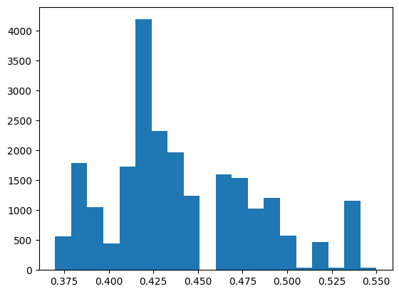

```python
df['gini'].hist(bins=20,grid=False) # Here is an OK-looking histogram
```

- Great, that helps show us how Gini is distributed
- What about bond? That's one of our key variables that we really care about

```python
print(df['bond'].value_counts(), '\n')
print(len(df['bond']), '\n')
```

```
bond
0.00        7344
1000.00     2066
2500.00     1827
1500.00     1627
2000.00     1189
            ...
58529.22       1
30695.00       1
61000.00       1
745.00         1
3813.49        1
Name: count, Length: 81, dtype: int64

22986
```

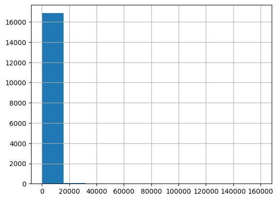

```python
df['bond'].hist() # This is not a very useful histogram...
```

## Variables with "Long Tails"

- That looks bad; not useful and misleading at best
  - Long tail distribution is a fundamental issue in ML, hard to predict what is not seen!
  - Unfortunately, most things of interest is not distributed normally.
- We often get graphs that are not meaningful to us because their values are **badly scaled**
- Computers, likewise, dislike variables with bad scaling: stable calculations become challenging when comparing numbers of very different magnitudes
- The traditional way to smooth them is to use the **(natural) logarithm** or `log()` function: This converts multiplication/division to addition/subtraction, or levels to growth rates, and shrinks large values significantly
- `log()` is only defined as a real number for for strictly positive numbers, so it forces us to drop zeros and negative numbers from visualizations or analysis: This is highly undesirable
- The **inverse hyperbolic sine** function, `arcsinh()`, is defined for any number, positive or negative, and has almost the same interpretation, so we often use it instead

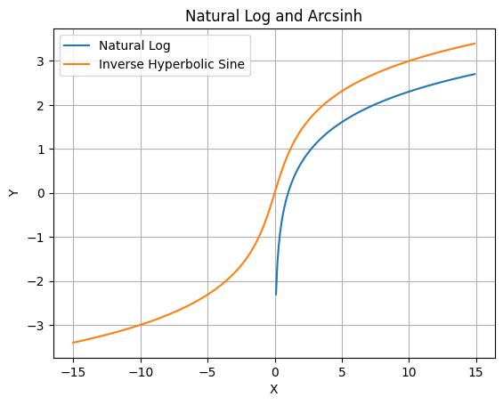

```python
# Quick matplotlib plot of log and arcsinh:
x = np.arange(-15,15,.1)
y1 = np.log(x)
y2 = np.arcsinh(x)
plt.plot(x,y1, label ='Natural Log')
plt.plot(x,y2, label='Inverse Hyperbolic Sine')
plt.xlabel("X")
plt.ylabel("Y")
plt.grid()
plt.legend(loc='upper left')
plt.title('Natural Log and Arcsinh')
plt.show()
```

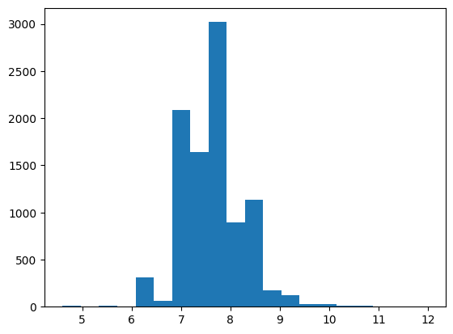

```python
df['bond_log'] = np.log(df['bond'])
# df['bond_log'].hist() # This crashes: We need to locate the non-infinte values
df.loc[df['bond_log']>0,'bond_log'].hist(bins=20,grid=False)
```

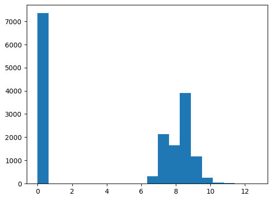

```python
df['bond_arcsinh'] = np.arcsinh(df['bond'])
df['bond_arcsinh'].hist(bins=20,grid=False) # Notice all the data at zero that log throws away
```

## Seaborn

- The Pandas plotting utilities are convenient: They're packaged with Pandas and can be called as `df['var'].thisplot()`
- They are not very extensible or aesthetically pleasing
- The Plotly and Altair packages are nice and generate interactive plots,
- Seaborn strikes a nice balance: The plots are pretty extensible, but not interactive, but the API is still simple
- Seaborn also makes it very easy to produce plots with multiple series on the same canvas, which will be a key tool for us

## Basic Plots in Seaborn

- It's nice that Pandas has built-in plotting utilities, but they're not great for building complex or attractive plots
- All the plots we made with Pandas can be done in Seaborn with almost the same syntax:
  - Histogram: `sns.histplot(df[varName])` or `sns.histplot(data=df,x=varName)`
  - Density: `sns.kdeplot(df[varName])` or `sns.kdeplot(data=df,x=varName)`
  - Boxplot: `sns.boxplot(df[varName])` or `sns.boxplot(data=df,x=varName)`
  - Scatterplot: `sns.scatterplot(df[varName1],df[varName2])` or `sns.scatterplot(data=df,x=varName1, y=varName2)`

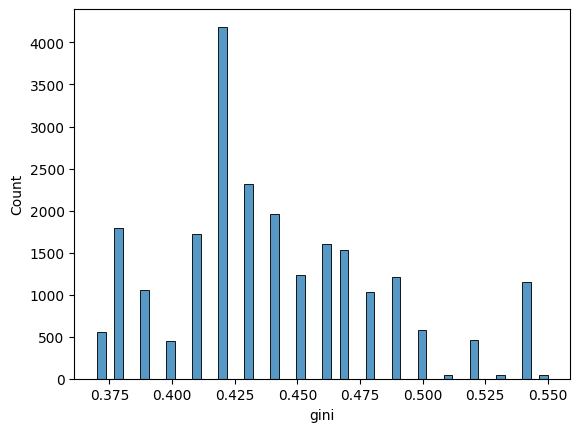

```python
import seaborn as sns # Import Seaborn

# Histogram:
var = 'gini'
sns.histplot(df[var]) # A histogram
#sns.histplot(data=df, x=var) # Same thing
plt.show()
```

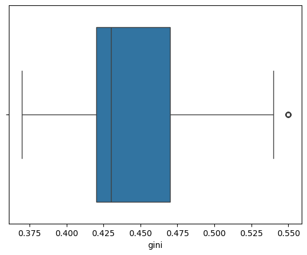

```python
# Boxplot:
var = 'gini'
#sns.boxplot(df[var]) # A boxplot
sns.boxplot(data=df, x=var) # Same thing, but horizontal
plt.show()
```

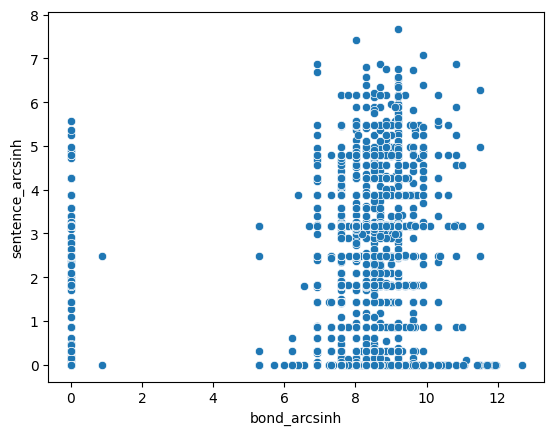

```python
# Scatterplot:
var1 = 'sentence_arcsinh'
var2 = 'bond_arcsinh'
sns.scatterplot(y=df[var1],x=df[var2]) # A scatterplot
#sns.scatterplot(data=df, y=var1, x=var2) # Same thing
plt.show()
```

## Titles and Labels

- Your plots are ultimately to communicate. If you don't provide this basic information, you're making it much harder for people to understand what you're doing.
  1. A title
  2. Legible horizontal and vertical axis labels
  3. A legend, if there is more than one series plotted
- We do this with `.set(title=...,xlabel=...,ylabel=...)`

```
[Text(0.5, 1.0, 'Gini Coefficient of Inequality'),
```

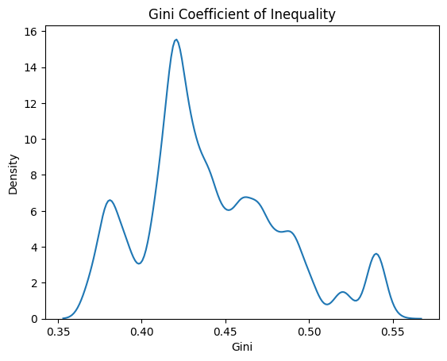

```python
var = 'gini'
fig = sns.kdeplot(df[var])
fig.set(title='Gini Coefficient of Inequality',
xlabel='Gini',
ylabel='Density')
```

## Statistics

- Our subsequent plots will involve a bit more statistical computation, so we'll pause and talk about some statistics concepts
- A **(sample) statistic** is a function of the data: We take a list of values, and aggregate it into a summary number(s) that helps us better understand the phenomenon we're interested in
- An example is the **mean** or **average**: We sum all of the values, and divide by the total number of values. If we have $N$ observations and the values are $(x_1, x_2, ..., x_N)$, the average is $$ \bar{x} = \dfrac{x_1+x_2+...+x_N}{N} = \dfrac{ \sum_{i=1}^N x_i }{N} $$ The intuition is, "Imagine you drew a number out of the hat. They're all drawn with equal probability. What kind of number do you expect to get?"
- The field of statistics, roughly, studies the behavior of sample statistics as the sample size $N$ gets large: What is the behavior of a sample statistic as we get lots of data? Does it approach the "true" value, if one exists?
- In EDA, we're typically using statistics as a way to summarize the data and understand its features, and not necessarily imputing a "deeper meaning" to them

## Always, always, always, look at your data

[figure not shown]

- How *useful* is it to say, "The average yearly salary of a lawyer is about $100k?"
- Statistics can be incredibly misleading

## Statistics: Measures of Central Tendency

- These statistics correspond to values around which the data are concentrated:
  - Mode: The most frequently occuring value in the data
  - Median: The value(s) at which half the population is above and half the population is below
  - Mean: The numeric average value of the data, $$ \bar{x} = \dfrac{x_1+x_2+...+x_N}{N} = \dfrac{ \sum_{i=1}^N x_i }{N} $$

```
Mean:  0.4406351210168901
Median:  0.43
Mode:  0    0.42
Name: gini, dtype: float64
```

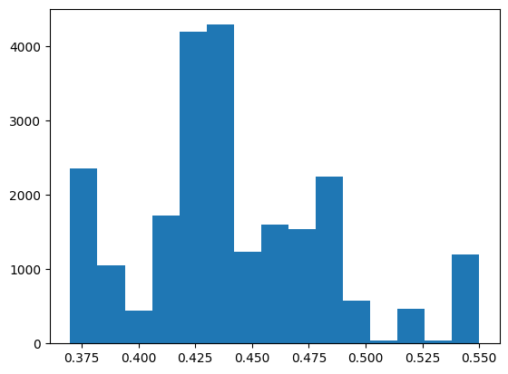

```python
var = 'gini'

df[var].hist(bins=15,grid=False)
print('Mean: ', df[var].mean() )
print('Median: ', df[var].median() )
print('Mode: ', df[var].mode() )
```

```
Mean:  4.686972979300787
Median:  7.600902709541988
Mode:  0    0.0
Name: bond_arcsinh, dtype: float64
```

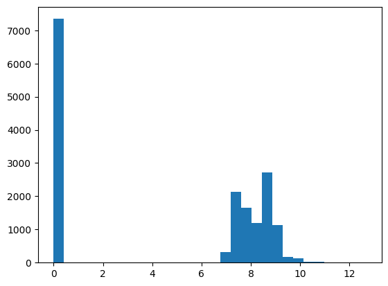

```python
df['bond_arcsinh'] = np.arcsinh(df['bond'])

var = 'bond_arcsinh'

df[var].hist(bins=30,grid=False)
print('Mean: ', df[var].mean() ) # Does anyone actually get 4.68697?
print('Median: ', df[var].median() )
print('Mode: ', df[var].mode() )
```

## Statistics: Measures of Dispersion

- In addition to the raw quantiles, we have a variety of statistics we can use to capture similar information about how "spread out" the data are:
  - Range: The minimum and maximum values of the data
  - Interquartile Range: The distance between the 25%-quantile and 75%-quantile, which includes the middle half of the data
  - Variance: The average squared distance from the mean, $$ s^2 = \dfrac{(x_1-\bar{x})^2 + (x_2 - \bar{x})^2 + ... + (x_N - \bar{x})^2}{N-1} = \dfrac{\sum_{i=1}^N (x_i-\bar{x})^2 }{N-1} $$ So take the value of each observation $i$, subtract off the mean $\bar{x}$, square that, and then divide by $N-1$. If the data are all clustered around $\bar{x}$, this will be small, but if the data are very spread out, this will be larger.
  - Standard Deviation: The square root of the variance, $$ s = \sqrt{s^2} = \sqrt{ \dfrac{\sum_{i=1}^N (x_i-\bar{x})^2 }{N-1} }$$

## Single Variable Visualization -> Distribution

- For either categorical or continuous variables, our goal is to accurately express information about the **frequency of different values**
- For categorical variables, the domain is composed of a finite number of responses, and the range is the count: It's a bar graph (a histplot with a categorical horizontal axis)
- For numeric variables, the domain is a range of real numeric values, and the range is the frequency/mass (histogram)
- This is giving us an estimate of $f(x)$, the probability density/mass function of a random variable $X$

## Categorical Data

- The most common way to represent relative frequencies of categorical variables is the bar graph, but I tend to use the histogram function to make them:

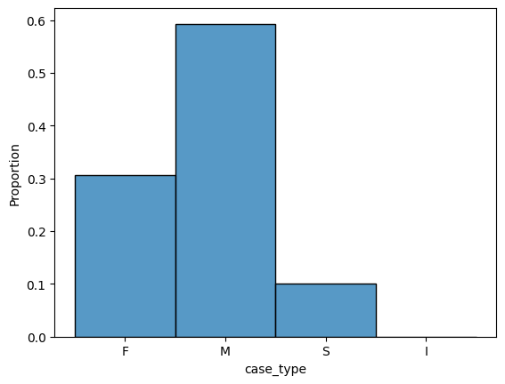

```python
import seaborn as sns
sns.histplot(data=df,x='case_type',stat='proportion')
```

- Notice the option, `stat = 'proportion'` . This force the vertical axis into proportions or probabilities, rather than counts.
- Later in the course, we'll discuss why this is a reasonable estimator $\hat{f}(x)$ of the true mass function $f(x)$, but you can do kernel smoothing on it, as we're about to look at for numeric data

## Numeric Data

- Numeric data are significantly more difficult to handle than categorical data, since their values are difficult to faithfully represent visually
- We'll build our way up to the kernel density plot as a leading solution
- To start, what's the most primitive way to look at the data?
- Let's use a rugplot, and just mark the points on the horizontal axis:

```python
import pandas as pd
import numpy as np
df = pd.read_csv('./data/pretrial_data.csv') # Load data
x = df['age'] # Age and Gini are nice numeric variables to play with
x = x[ x.isna()==False ].sample(50, random_state=10) # I only want 50 observations for today, not 23k
x= x.to_numpy() # Drop missings and convert x to numpy array; Pandas index is tedious

## Some stats about X:
sd = np.std(x) # standard deviation of x
N = len(x) # number of observations
med_x = np.median(x) # median of x
min_x = min(x) # min of x
max_x = max(x) # max of x
```

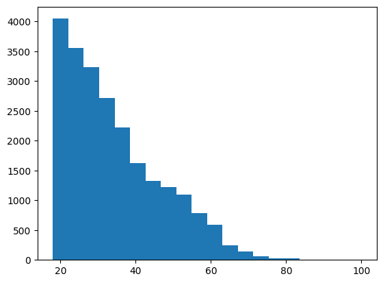

```python
var = 'age'
df[var].hist(bins=20,grid=False) # Here is an OK-looking histogram
```

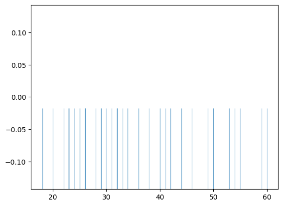

```python
import matplotlib.pyplot as plt
# print(x)
sns.rugplot(x,height=.44, alpha=.3)
plt.show()
```

## The Data

- We want a better representation of the frequency of occurrence for each value of $X$
- What we really want is some kind of estimate of $f(x)$: The density or mass function of $X$
- This motivates the idea of a histogram: Break the axis into bins, and plot by frequency: It's essentially a bargraph for small windows of values, and we're turning a numeric variable into a categorical one (this is also its big flaw)

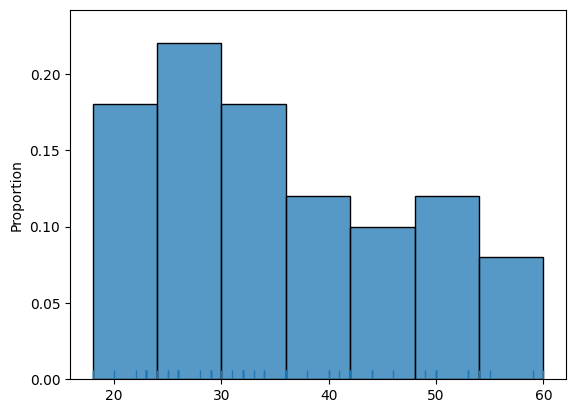

```python
sns.rugplot(x)
sns.histplot(x,stat='proportion')
```

## The Histogram

- We like the histogram: Simple, effective, etc.
- Is there a principled way to pick the number of bins?
- Which one do you prefer:

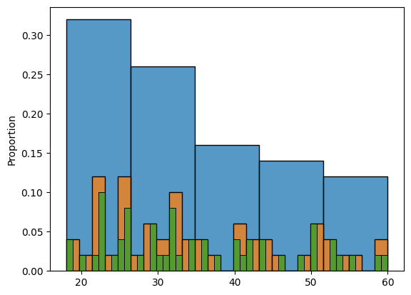

```python
sns.histplot(x,bins=5,stat='proportion')
sns.histplot(x,bins=25,stat='proportion')
sns.histplot(x,bins=50,stat='proportion')
```

## Kernel Density Plots

- To avoid this issue of discrete bins, we have an alternative, superior tool
- The kernel density plot works slightly differently:
  - Instead of a point being a "spike" like the rug plot, associate a point with a function: Draw a little bell around it, for example. This is called a **kernel function**.
  - This smoothing reduces the jumpy behavior of the graph, and the unpredictability of how it behaves as we change the number of bins
  - This introduces bias, since we're smearing the data across the axis a bit, but reduces variance, since small changes in $X$ don't lead to huge changes in our plot
- We have a variable that allows us to tune how much smoothing there is, called the **bandwidth**, $h$
- The most popular kernel is the Normal of Gaussian kernel with bandwidth $h$, $$ k(z) = \dfrac{1}{\sqrt{2\pi}h} e^{-(z/h)^2}, $$
- The next plot shows a normal kernel as the bandwidth goes down: It becomes more tightly concentrated around $0$ as $h$ gets smaller
- In this case, the bandwidth is like standard deviation of a Normally distributed random variable, but kernel density estimation is more general than that
- Important intuition: Small $h$/bandwidth means we're close to a rug plot, and large $h$/bandwidth means we're "smearing" the data more on the horizontal axis

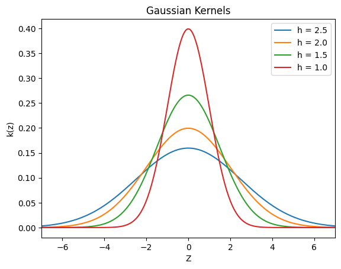

```python
M = 500 # steps for grid
grid = np.linspace(-7,7,M) # Grid for plotting values

def normal_kernel(center,bandwidth):
    """ Normal kernel function. """
    density = np.exp( -(( (grid-center)/bandwidth)**2)/2 ) / (bandwidth * np.sqrt(2*np.pi))
    return density

## Compute normal kernels around 0 for various bandwidths:
y_10 = normal_kernel(0,1.0)
y_15 = normal_kernel(0,1.5)
y_20 = normal_kernel(0,2.0)
y_25 = normal_kernel(0,2.5)

## Plot kernel functions:
fig = sns.lineplot(x=grid,y=y_25, label='h = 2.5')
fig.set_xlim(-7, 7)
fig.set(title="Gaussian Kernels", xlabel='Z', ylabel='k(z)')
sns.lineplot(x=grid,y=y_20, label='h = 2.0')
sns.lineplot(x=grid,y=y_15, label='h = 1.5')
sns.lineplot(x=grid,y=y_10, label='h = 1.0')
plt.show()
```

## Kernels

- For each data point, we'll center one of these kernels at that value, as $$ k(x) = \dfrac{1}{h \sqrt{2\pi}}e^{-( (x_i-x)/h)^2} $$
- For the age variable from the justice data, let's plot each of these little bell curves/kernels
- What bandwidth should we pick? There is a rule-of-thumb or plug-in estimate that usually gives pretty good results, called **Silverman's Plug-in Estimate**: $$ h_{s} = 1.06 \times \sigma \times N^{-1/5} $$
- In practice, we might want to use a data-driven choice for $h$, and we'll cover that later in the course (cross validation)
- This shows you how each value in the rugplot gets its own bell curve/kernel function:

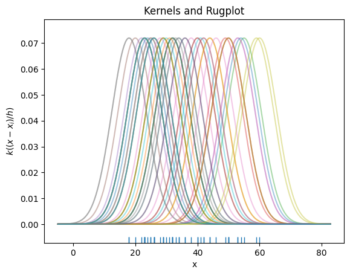

```python
h = 1.06 * sd * N**(-1/5) # Silverman's plug-in bandwidth
h_s = h # save the plug-in value for later

M = 500 # steps for grid
grid = np.linspace(min_x-2*sd,max_x+2*sd,M) # X grid, +/2 standard deviations of median

kde = 0*grid
fig = sns.rugplot(x) # Start with a rugplot
fig.set(title="Kernels and Rugplot", xlabel='x', ylabel='$k( (x-x_i)/h )$')
for i in range( len(x) ): # For each data point...
    density = normal_kernel(x[i],h) # Compute the kernel function for this data point
    sns.lineplot(x=grid,y=density, alpha = .4) # Plot the kernel
    kde += density # Add this density to the overall KDE
kde = kde/N
plt.show()
```

## The Kernel Density Plot

```
[Text(0.5, 1.0, 'Our Kernel Density Plot'),
```

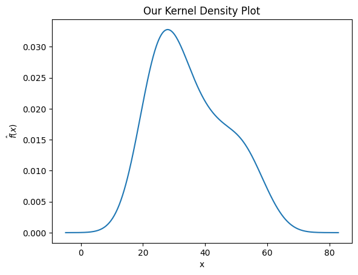

```python
fig = sns.lineplot(x=grid,y=kde) # Our KDE estimator
fig.set(title="Our Kernel Density Plot", xlabel='x', ylabel='$\\hat{f}(x)$')
```

```
[Text(0.5, 1.0, "Seaborn's Kernel Density Plot"),
```

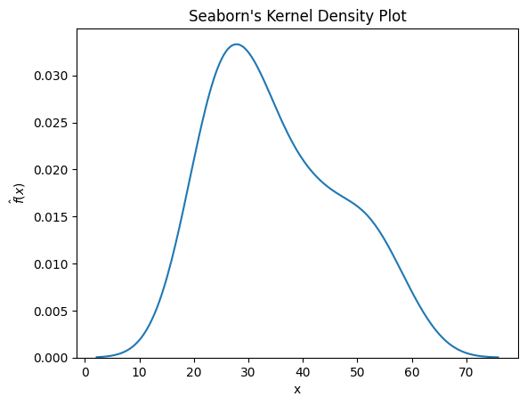

```python
fig = sns.kdeplot(x) # Seaborn's KDE estimator
fig.set(title="Seaborn's Kernel Density Plot", xlabel='x', ylabel='$\\hat{f}(x)$')
```

## Alternative Bandwidth

- Silverman's plug-in is based on a solid mathematical approximation, and is usually pretty good
- But we're not zombies, and sometimes it is not a good approximation: What if we want to play with the bandwidth?

```
Plug-in Bandwidth:  5.541666089858518
Our Bandwidth:  3
```

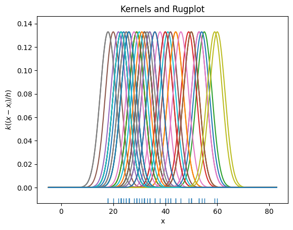

```python
print('Plug-in Bandwidth: ', h_s)
h= 3 # Let's choose a different bandwidth
print('Our Bandwidth: ', h)
kde = 0*grid

## Rugplot and kde, same as earlier:
fig = sns.rugplot(x)
fig.set(title="Kernels and Rugplot", xlabel='x', ylabel='$ k((x-x_i)/h)$')
for i in range( len(x) ):
    density = normal_kernel(x[i],h)
    sns.lineplot(x=grid,y=density)
    kde += density
plt.show()
```

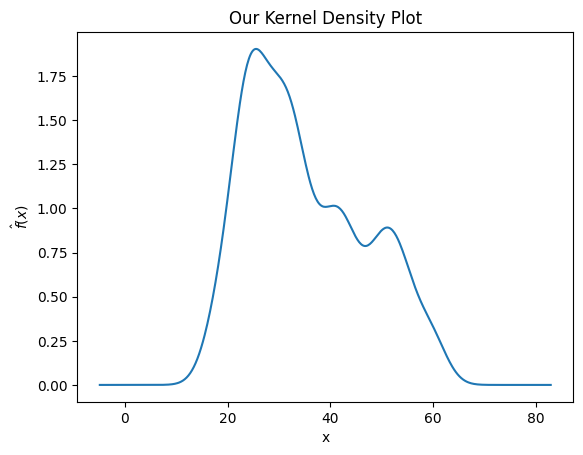

```python
fig = sns.lineplot(x=grid,y=kde)
fig.set(title="Our Kernel Density Plot", xlabel='x', ylabel='$\\hat{f}(x)$')
plt.show()
```

```
Plug-in Bandwidth:  5.541666089858518
```

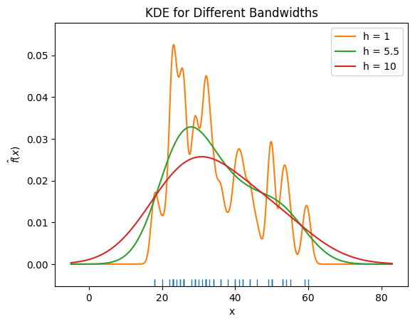

```python
print('Plug-in Bandwidth: ', h_s)
H = [1, 5.5, 10] # Let's choose a different bandwidth

fig = sns.rugplot(x)
fig.set(title="KDE for Different Bandwidths", xlabel='x', ylabel='$ \\hat{f}(x)$')
for h in H: # For each alternative bandwidth...
    kde = 0*grid # New kernel density values
    for i in range( len(x) ): # For each value in the data...
        density = normal_kernel(x[i],h) # Compute the kernel for this data point
        kde += density # Add to the kernel density
    kde = kde/N # Normalize the kernel density by 1/N
    sns.lineplot(x=grid,y=kde,label='h = ' + str(h)) # Add this series to the graph
plt.show() # Show the completed graph
```

## Overfitting and Underfitting

- We've already arrived at the central issue in machine learning
- Models often have hyperparameters like the bandwidth $h$ that give us degrees of freedom in tuning models: We learn about the underlying model and data by playing with it, but we typically don't have an obvious, uniquely best way to pick hyperparameters like $h$
- When we pick a very tight bandwidth, the kernel density plot seems to be overconfident about how much information it can extract from the limited data available: This is called **overfitting**
- When we pick a very wide bandwidth, the kernel density plot seems shapeless and timid about how much information it can extract from the data versus the model: This is called **underfitting**
- What's happening here is a **bias-variance trade-off**:
  - We can pick a very tight bandwidth to reduce bias... but the lack of smoothing makes the predictions very high variance (the model overfits the data)
  - We can pick a very wide bandwidth to reduce variance... but this excess smoothing makes the bias large (the model underfits the data)
  - We'll cover the bias-variance trade-off in depth later in the course, but this is a first glimpse of the concept
- The job of machine learning is largely to develop methods by which to fit models to data in ways that avoid overfitting and underfitting, and deliver consistent and reliable predictions
- While plug-in methods are nice, there are data-driven tools to pick the bandwidth that we'll cover later in the course (least squares cross validation, likelihood cross validation)

## Alternative Kernel

- The general definition of a kernel density estimator is $$ \hat{f}(x) = \dfrac{1}{N} \sum_{i=1}^N \dfrac{1}{h} k \left( \dfrac{x-x_i}{h} \right) $$ where an arbitrary $k(z)$ replaces the Normal density function
- Why? A few reasons:
  - In some settings, like when $X$ is time, it's unrealistic to smooth symmetrically near 0, since you'll get negative values for time
  - The bandwidth might be more interpretable or easily estimated
  - There is actually a known optimal kernel function, called the Epanechnikov kernel, and we might want to use it
  - If you know that there are spots where the data vanish, an alternative kernel won't oversmooth like the Gaussian and suggest there are data there
- Instead of the Normal kernel, $$ k(z) = \dfrac{1}{\sqrt{2\pi}}e^{-z^2} $$ let's use the uniform kernel, $$ k(z) = \begin{cases} 1/2, & |z| \le 1\\ 0, & \text{otherwise} \end{cases} $$
- This gives us something closer to a classic histogram, since we're using the "bump function" as a kernel instead of a bell curve
- Our new kernel density estimator is $$ \hat{f}(x) = \dfrac{1}{N} \sum_{i=1}^N \mathbb{I} \left\lbrace \left| \dfrac{x-x_i}{h} \right| \le 1 \right\rbrace \times \dfrac{1}{2h} $$ where the indicator function $\mathbb{I} \{A\}$ is 1 if $A$ is true, and zero otherwise.

```
[Text(0.5, 1.0, 'The Bump Function'),
```

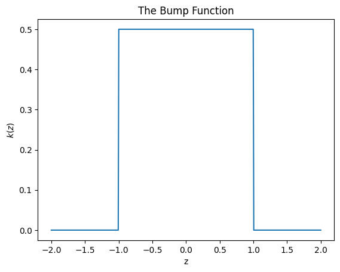

```python
gr = np.linspace(-2,2,M)
kr = (np.abs(gr) <= 1) * .5
fig = sns.lineplot(x=gr,y=kr) # Bump function
fig.set(title="The Bump Function", xlabel='z', ylabel='$ k(z)$')
```

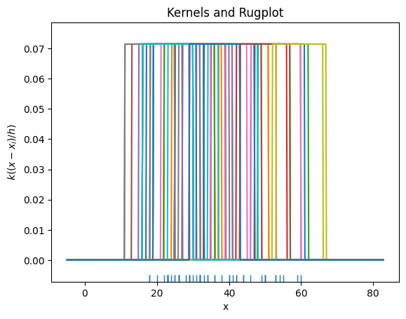

```python
h = 7 # bandwidth

def uniform_kernel(center,bandwidth):
    """ Uniform kernel function. """
    density = ( np.abs( (grid-center)/bandwidth )<=1 )*(.5/h)
    return density

fig = sns.rugplot(x)
fig.set(title="Kernels and Rugplot", xlabel='x', ylabel='$ k((x-x_i)/h)$')
kde = 0*grid
for i in range( len(x) ):
    density = uniform_kernel(x[i],h)
    sns.lineplot(x=grid,y=density)
    kde += density
plt.show()
```

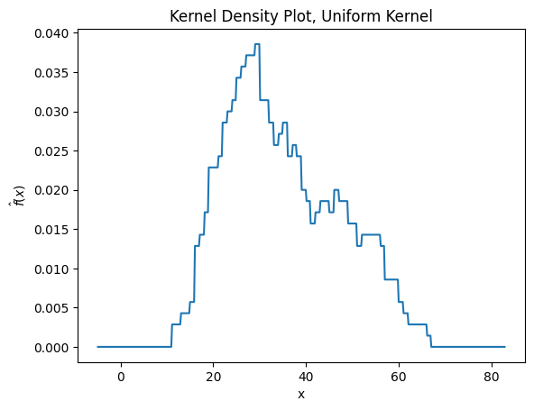

```python
kde=kde/N # Normalize the sum of kernels
fig = sns.lineplot(x=grid,y=kde)
fig.set(title="Kernel Density Plot, Uniform Kernel", xlabel='x', ylabel='$ \\hat{f}(x)$')
plt.show()
```

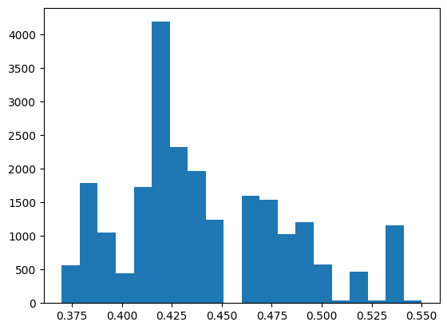

```python
var = 'gini'
df[var].hist(bins=20,grid=False) # Here is an OK-looking histogram
```

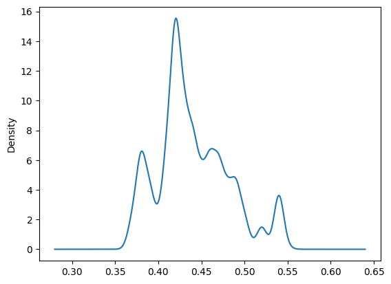

```python
df[var].plot.density() # The kernel density plot for gini
```

- The upside will be that it's easy to visualize many series at once, grouped by a categorical variable, and the choice of "bins" isn't as arbitrary (there are a lot of good ways to pick the **bandwidth**)
- The downside is that if the data have big spikes, the kernel density plot struggles to represent that faithfully, because it is trying to smooth everything out:

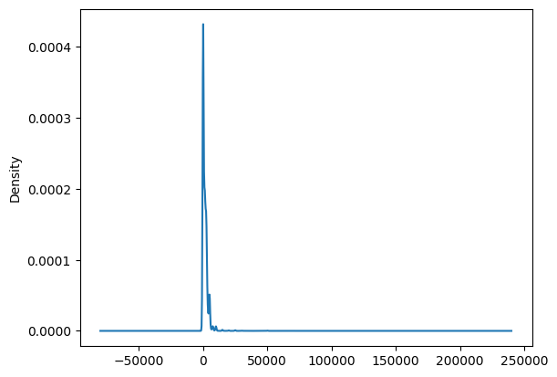

```python
var = 'bond'
df[var].plot.density() # Not so good for bond
```

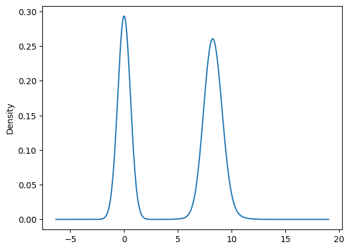

```python
# the discreteness of the bond makes this plot look off:

var = 'bond_arcsinh'
df[var].plot.density()
```

## Statistics: Measures of Rank

- Imagine lining the data up by magnitude, from smallest to largest
- The **p-th percentile** is the value for which $p\%$ of the population is below $p$'s value and $(1-p)\%$ of the population is above $p$'s value
- If you use decimals instead of percents, like $.05$ for $5\%$ or $.50$ for $50\%$, the word **quantile** is typically used
- This ranks observations from smallest to largest by the proportion of the sample it "defeats"
- Why? Quantiles and the median are robust to outliers: Moving extremely large or small values won't affect the median or significantly change the rankings.
- The **Empirical Cumulative Distribution Function (ECDF)** essentially plots all the quantiles

```
Minimum:  0.37
0th quantile:  0.37
.05 quantile:  0.38
.10 quantile:  0.38
.25 quantile:  0.42
.50 quantile:  0.43
.75 quantile:  0.47
.90 quantile:  0.5
.95 quantile:  0.54
1.00 quantile:  0.55
Sample Maximum: 0.55
```

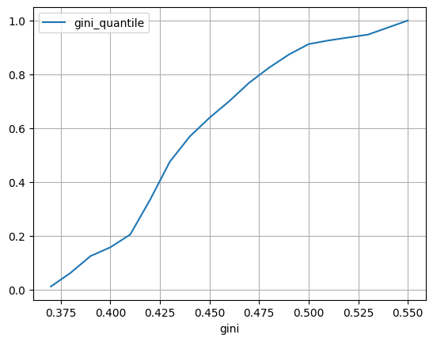

```python
# Sample quantiles for the gini variable:
var = 'gini'
print('Minimum: ', df[var].min())
print('0th quantile: ', df[var].quantile(0))
print('.05 quantile: ', df[var].quantile(.05))
print('.10 quantile: ', df[var].quantile(.10))
print('.25 quantile: ', df[var].quantile(.25))
print('.50 quantile: ',df[var].quantile(.50))
print('.75 quantile: ',df[var].quantile(.75))
print('.90 quantile: ',df[var].quantile(.90))
print('.95 quantile: ',df[var].quantile(.95))
print('1.00 quantile: ',df[var].quantile(1))
print('Sample Maximum:', df[var].max())

# A quick Empirical Distribution Function plot:
df['gini_quantile'] = df['gini'].rank(method = 'average', pct = True) # Ranks the values
df.sort_values('gini').plot(x = 'gini', y = 'gini_quantile', grid = True)
```

```
Minimum:  0.0
0th quantile:  0.0
.05 quantile:  0.0
.10 quantile:  0.0
.25 quantile:  0.0
.50 quantile:  1000.0
.75 quantile:  2500.0
.90 quantile:  3500.0
.95 quantile:  5000.0
1.00 quantile:  160000.0
Sample Maximum: 160000.0
```

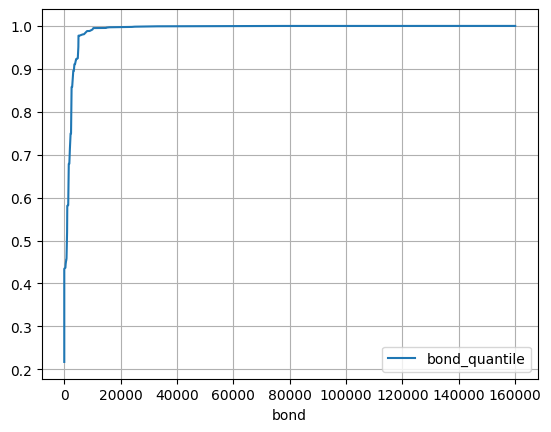

```python
# Sample quantiles for the bond variable:
var = 'bond'
print('Minimum: ', df[var].min())
print('0th quantile: ', df[var].quantile(0))
print('.05 quantile: ', df[var].quantile(.05))
print('.10 quantile: ', df[var].quantile(.10))
print('.25 quantile: ', df[var].quantile(.25))
print('.50 quantile: ',df[var].quantile(.50))
print('.75 quantile: ',df[var].quantile(.75))
print('.90 quantile: ',df[var].quantile(.90))
print('.95 quantile: ',df[var].quantile(.95))
print('1.00 quantile: ',df[var].quantile(1))
print('Sample Maximum:', df[var].max())

# A quick Empirical Distribution Function plot:
df['bond_quantile'] = df['bond'].rank(method = 'average', pct = True) # Ranks the values
df.sort_values('bond').plot(x = 'bond', y = 'bond_quantile', grid = True)
```